# Expolring Iris Dataset with Caret

First, We’ll be loading the relevant packages.

```r
library(caret)
library(ellipse)
library(scales)
```

Then, the dataset is loaded. (Note: The Iris dataset is included with R.)

```r
data("iris")
dataset <- iris
```

Now we want to set aside some of the data to test the model after it is trained. Every Peice of data is not used for training the model. The following code will set aside 20% of data for testing and 80% for training the model.

```r
validation_index <- createDataPartition(dataset$Species, p = 0.80, list = F)
# Selecting 20% of data for testing
validation <- dataset[-validation_index,]
# Using the rest of 80% data for training the model.
dataset <- dataset[validation_index,]
```

Now we’ll take a look at the dataset.

1. Dimensions of the dataset

```r
dim(dataset)
```

```
[1] 120   5
```

2. Types of attributes

```r
sapply(dataset, class)
```

```
Sepal.Length  Sepal.Width Petal.Length  Petal.Width      Species
   "numeric"    "numeric"    "numeric"    "numeric"     "factor"
```

3. Inspect a first few rows of the data.

```r
head(dataset)
```

|  | Sepal.Length | Sepal.Width | Petal.Length | Petal.Width | Species |
| --- | --- | --- | --- | --- | --- |
| 1 | 5.1 | 3.5 | 1.4 | 0.2 | setosa |
| 2 | 4.9 | 3.0 | 1.4 | 0.2 | setosa |
| 4 | 4.6 | 3.1 | 1.5 | 0.2 | setosa |
| 5 | 5.0 | 3.6 | 1.4 | 0.2 | setosa |
| 6 | 5.4 | 3.9 | 1.7 | 0.4 | setosa |
| 7 | 4.6 | 3.4 | 1.4 | 0.3 | setosa |

4. List the levels for the class

```r
levels(dataset$Species)
```

```
[1] "setosa"     "versicolor" "virginica"
```

5. Summarize the class distribution

```r
percentage <- prop.table(table(dataset$Species)) * 100
cbind(freq = table(dataset$Species), percentage = percentage)
```

```
           freq percentage
setosa       40   33.33333
versicolor   40   33.33333
virginica    40   33.33333
```

We can see that the three of levels ‘setosa’, ‘versicolor’ and ‘virginica’ have equal amount of entries. (33.333% Each) 6. A summary of dataset

```r
summary(dataset)
```

```
  Sepal.Length    Sepal.Width     Petal.Length    Petal.Width          Species
 Min.   :4.300   Min.   :2.000   Min.   :1.000   Min.   :0.100   setosa    :40
 1st Qu.:5.100   1st Qu.:2.800   1st Qu.:1.600   1st Qu.:0.300   versicolor:40
 Median :5.800   Median :3.000   Median :4.300   Median :1.300   virginica :40
 Mean   :5.862   Mean   :3.046   Mean   :3.766   Mean   :1.192
 3rd Qu.:6.400   3rd Qu.:3.300   3rd Qu.:5.100   3rd Qu.:1.800
 Max.   :7.900   Max.   :4.400   Max.   :6.900   Max.   :2.500
```

## Visualizing Dataset

1. Univariate Plots (Plots of each variable.) Splitting dataset into input attributes(X) and target attributes(y).

```r
X <- dataset[,1:4]
y <- dataset[,5]
```

Since all values of X are numeric, Box and whiskers plots are created for each.

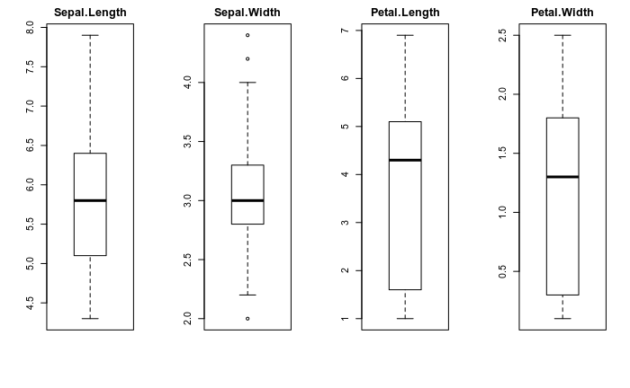

```r
par(mfrow=c(1,4))
for (i in 1:4) {
  boxplot(X[,i], main=names(iris)[i])
}
```

Creating a barplot for taget attributes. There should be three even bars.

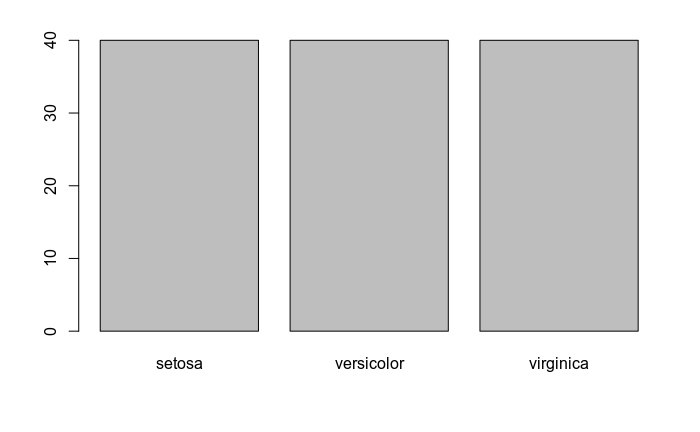

```r
plot(y)
```

2. Multivariate Plots Scatterplots of all pair of attributes and color the points by class.
- Scatterplot matrix

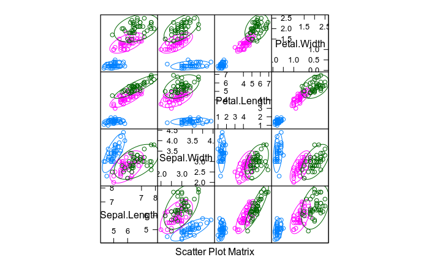

```r
featurePlot(x=X, y=y,plot = "ellipse")
```

- Box and whiskers plot for each varibale, separated for each class.

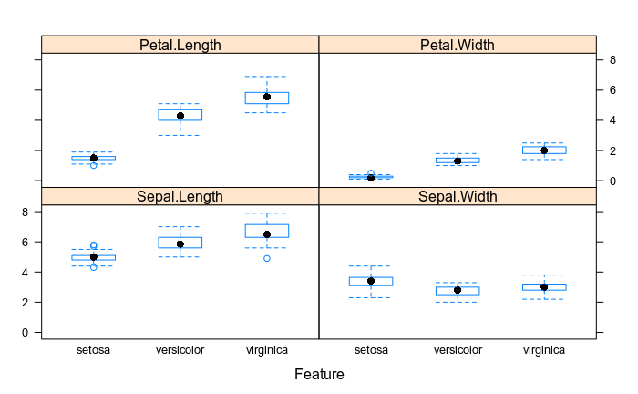

```r
featurePlot(x=X, y=y, plot = "box")
```

- Probability density plots for each attribute, to understand the distribution.

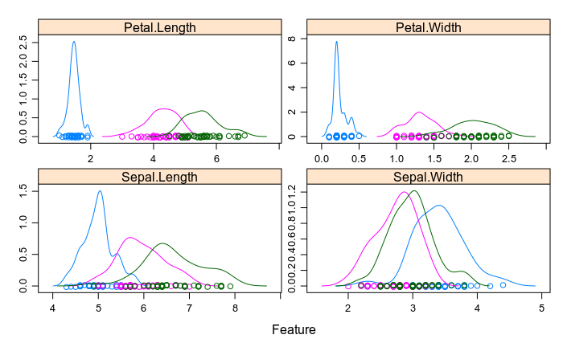

```r
scales <- list(x=list(relation="free"), y=list(relation="free"))
featurePlot(x=X, y=y, plot="density", scales=scales)
```

## Evaluating algorithms

Run algorithms using 10-fold cross validation. This will split our dataset into 10. Train in 9 and test in 1.

```r
control <- trainControl(method = "cv", number = 10)
```

We’ll be evaluating the following algorithms.

These algorithms contain **simple linear(LDA)**, **nonlinear(CART, kNN)** and **complex nonlinear(SVM, RF)** methods. Random number is resetted each time to ensure that the evaluation of each algorithm is done on the same data splits. It makes data directly comparable.

I. Linear Algorithms

```r
# LDA
set.seed(7)
fit.lda <- train(Species~., data = dataset, method = "lda", metric = "Accuracy", trControl = control)
```

2. Nonlinear Algorithms

```r
# CART
set.seed(7)
fit.cart <- train(Species~., data = dataset, method = "rpart", metric = "Accuracy", trControl = control)
# kNN
set.seed(7)
fit.knn <- train(Species~., data = dataset, method = "knn", metric = "Accuracy", trControl = control)
```

3. Advanced ALgorithms

```r
# SVM
set.seed(7)
fit.svm <- train(Species~., data = dataset, method = "svmRadial", metric = "Accuracy", trControl = control)
# Random Forest
set.seed(7)
fit.rf <- train(Species~., data = dataset, method = "rf", metric = "Accuracy", trControl = control)
```

## Comparing the models

Now we have 5 models and accuracy estimations for each of them. They can be compared and then the best one can be selected. A list of created models is summarized.

```r
results <- resamples(list(lda = fit.lda, cart = fit.cart, knn = fit.knn, svm = fit.svm, rf = fit.rf))
summary(results)
```

```
Call:
summary.resamples(object = results)

Models: lda, cart, knn, svm, rf
Number of resamples: 10

Accuracy
          Min.   1st Qu.    Median      Mean   3rd Qu. Max. NA's
lda  0.9166667 0.9375000 1.0000000 0.9750000 1.0000000    1    0
cart 0.7500000 0.9166667 0.9166667 0.9166667 0.9166667    1    0
knn  0.8333333 0.9166667 1.0000000 0.9583333 1.0000000    1    0
svm  0.8333333 0.9166667 0.9166667 0.9333333 1.0000000    1    0
rf   0.7500000 0.9166667 0.9166667 0.9250000 0.9791667    1    0

Kappa
      Min. 1st Qu. Median   Mean 3rd Qu. Max. NA's
lda  0.875 0.90625  1.000 0.9625 1.00000    1    0
cart 0.625 0.87500  0.875 0.8750 0.87500    1    0
knn  0.750 0.87500  1.000 0.9375 1.00000    1    0
svm  0.750 0.87500  0.875 0.9000 1.00000    1    0
rf   0.625 0.87500  0.875 0.8875 0.96875    1    0
```

Comapre accuracy of models using a plot

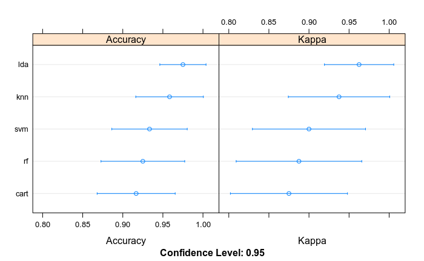

```r
dotplot(results)
```

As you can see, The best algorithm with the highest accuracy is LDA.

Summarize results for LDA model

```r
print(fit.lda)
```

```
Linear Discriminant Analysis

120 samples
  4 predictor
  3 classes: 'setosa', 'versicolor', 'virginica'

No pre-processing
Resampling: Cross-Validated (10 fold)
Summary of sample sizes: 108, 108, 108, 108, 108, 108, ...
Resampling results:

  Accuracy  Kappa
  0.975     0.9625
```

Making predictions and estimating skill of LDA on the validation dataset.

```r
predictions <- predict(fit.lda, validation)
confusionMatrix(predictions, validation$Species)
```

```
Confusion Matrix and Statistics

            Reference
Prediction   setosa versicolor virginica
  setosa         10          0         0
  versicolor      0         10         0
  virginica       0          0        10

Overall Statistics

               Accuracy : 1
                 95% CI : (0.8843, 1)
    No Information Rate : 0.3333
    P-Value [Acc > NIR] : 4.857e-15

                  Kappa : 1

 Mcnemar's Test P-Value : NA

Statistics by Class:

                     Class: setosa Class: versicolor Class: virginica
Sensitivity                 1.0000            1.0000           1.0000
Specificity                 1.0000            1.0000           1.0000
Pos Pred Value              1.0000            1.0000           1.0000
Neg Pred Value              1.0000            1.0000           1.0000
Prevalence                  0.3333            0.3333           0.3333
Detection Rate              0.3333            0.3333           0.3333
Detection Prevalence        0.3333            0.3333           0.3333
Balanced Accuracy           1.0000            1.0000           1.0000
```

As you can see, the LDA algorithm’s accuracy is 100%. This model can be safely assumed as a good model to use with other real-life flower samples.